# DATA607 Assignment 4: Tidying and Transformation Data

Albert Gilharry

27 February 2018

## Intro

**For this assignment we were given a data set containing on time and delay information of 2 airlines.** **We were tasked with tidying, transforming, and analyzing the data.** **My solution is documented below**

## Load Libraries

```r
library("dplyr")
library("tidyr")
library("tidyverse")
```

## My CSV

Below is an image of the CSV file I created from the table in the assignment document.

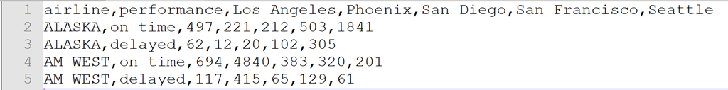

## Load CSV

```r
raw_data <- read.csv("data/data.csv", sep = ",", header = TRUE, stringsAsFactors=FALSE)
print(raw_data)
```

```
##   airline performance Los.Angeles Phoenix San.Diego San.Francisco Seattle
## 1  ALASKA     on time         497     221       212           503    1841
## 2  ALASKA     delayed          62      12        20           102     305
## 3 AM WEST     on time         694    4840       383           320     201
## 4 AM WEST     delayed         117     415        65           129      61
```

## Tidy Data

**Use the `gather` function to have the city as rows, set have their respective flights as a `counts` column.**

```r
raw_data = gather(raw_data, "city", "count", 3:7)
print(raw_data)
```

```
##    airline performance          city count
## 1   ALASKA     on time   Los.Angeles   497
## 2   ALASKA     delayed   Los.Angeles    62
## 3  AM WEST     on time   Los.Angeles   694
## 4  AM WEST     delayed   Los.Angeles   117
## 5   ALASKA     on time       Phoenix   221
## 6   ALASKA     delayed       Phoenix    12
## 7  AM WEST     on time       Phoenix  4840
## 8  AM WEST     delayed       Phoenix   415
## 9   ALASKA     on time     San.Diego   212
## 10  ALASKA     delayed     San.Diego    20
## 11 AM WEST     on time     San.Diego   383
## 12 AM WEST     delayed     San.Diego    65
## 13  ALASKA     on time San.Francisco   503
## 14  ALASKA     delayed San.Francisco   102
## 15 AM WEST     on time San.Francisco   320
## 16 AM WEST     delayed San.Francisco   129
## 17  ALASKA     on time       Seattle  1841
## 18  ALASKA     delayed       Seattle   305
## 19 AM WEST     on time       Seattle   201
## 20 AM WEST     delayed       Seattle    61
```

Use the `spread` function to create `ontime` and `delayed` columns. This is makes it easier to visualize the data.

```r
raw_data = spread(raw_data, "performance", "count")
print(raw_data)
```

```
##    airline          city delayed on time
## 1   ALASKA   Los.Angeles      62     497
## 2   ALASKA       Phoenix      12     221
## 3   ALASKA     San.Diego      20     212
## 4   ALASKA San.Francisco     102     503
## 5   ALASKA       Seattle     305    1841
## 6  AM WEST   Los.Angeles     117     694
## 7  AM WEST       Phoenix     415    4840
## 8  AM WEST     San.Diego      65     383
## 9  AM WEST San.Francisco     129     320
## 10 AM WEST       Seattle      61     201
```

## Analysis: Which Airline Performed Better?

**To find out, lets answer the following questions?**

- What are their respective market shares?

```r
total_flights =  sum(raw_data$`on time`) + sum(raw_data$`delayed`)
mutate(raw_data, flights = delayed + `on time`) %>%
  group_by(airline) %>%
    summarise(airline_total=(sum(flights)/total_flights))
```

```
## # A tibble: 2 x 2
##   airline airline_total
##   <chr>           <dbl>
## 1 ALASKA          0.343
## 2 AM WEST         0.657
```

**AM WEST has an advantageous 65.7% market share when compared to ALASKA at only 34.3%.**

- Do the market shares differ across cities?

**This may be better shown by a plot.**

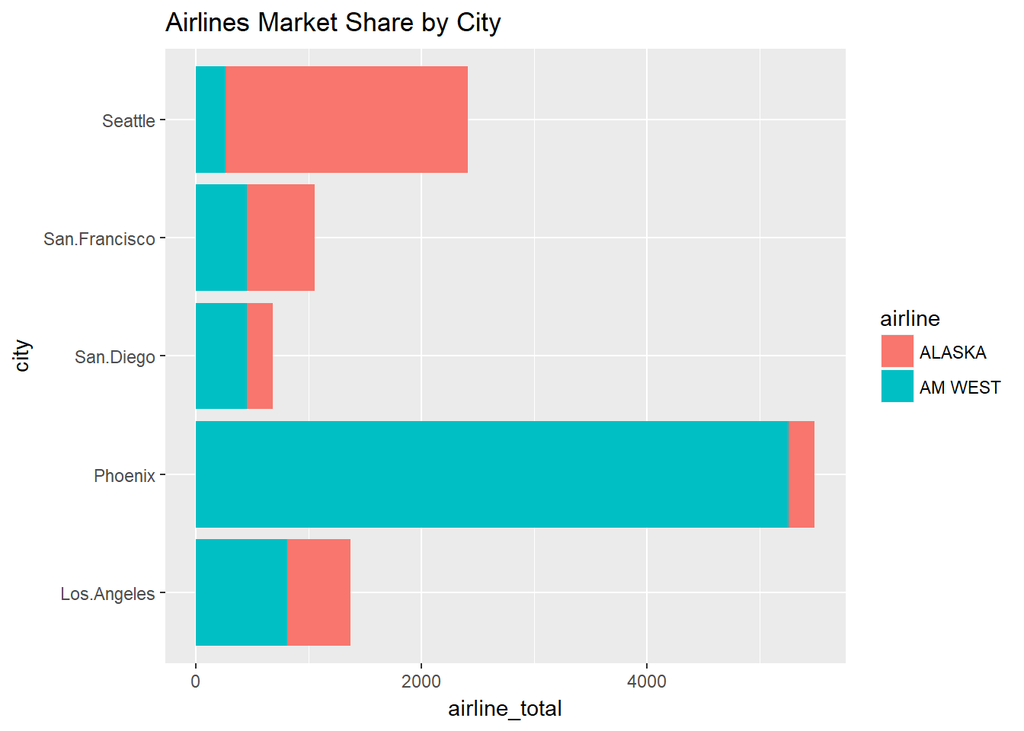

```r
      ggplot(data = mutate( raw_data, flights = delayed + `on time`) %>%
               group_by(city,airline) %>%
               summarise(airline_total=(sum(flights))),
             aes(x = city, y = airline_total,fill=airline)) +
                geom_bar(stat = "identity") +
                coord_flip() +
                labs(title = "Airlines Market Share by City")
```

**The plot shows that AM WEST has a larger market share in 3 of the 5 cities and it dominates in Phoenix. ALASKA dominates in Seattle but at a significantly lower magnitude than AM WEST’s domination in Phoenix.**

- What is each airline overall on time ratio?

```r
  select(raw_data, -city) %>%
  group_by(airline) %>%
    summarise(`on time rate`=( sum(`on time`)/( sum(`on time`) + sum(`delayed`) ) ) )
```

```
## # A tibble: 2 x 2
##   airline `on time rate`
##   <chr>            <dbl>
## 1 ALASKA           0.867
## 2 AM WEST          0.891
```

**AM WEST has a higher on time rate of 89.1% when compared to ALASKA at 86.7%**

- Would you consider choosing an airline based on your destination?

**To answer this, lets compare the on time performance of airlines by city.**

**Firstly, lets do a visual.**

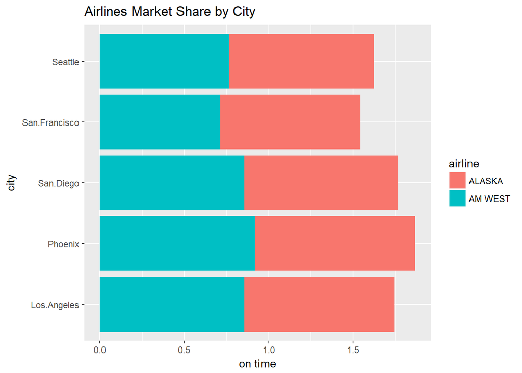

```r
 data =  select(raw_data,everything()) %>%
  group_by(airline,city) %>%
    summarise(`on time`=( sum(`on time`)/( sum(`on time`) + sum(`delayed`) ) ) ) %>%
    arrange(city)

ggplot(data = data, aes(x = city, y = `on time`,fill=airline)) +
                geom_bar(stat = "identity") +
                coord_flip() +
                labs(title = "Airlines Market Share by City")
```

**Strangely it seems the ALASKA performs better, we need to look at the data to be sure.**

```r
print(spread(data,city,`on time`))
```

```
## # A tibble: 2 x 6
## # Groups:   airline [2]
##   airline Los.Angeles Phoenix San.Diego San.Francisco Seattle
##   <chr>         <dbl>   <dbl>     <dbl>         <dbl>   <dbl>
## 1 ALASKA        0.889   0.948     0.914         0.831   0.858
## 2 AM WEST       0.856   0.921     0.855         0.713   0.767
```

**This is interesting! Alaska has a higher on time rate in every city, despite AM WEST having a higher overall on time rate! ALASKA’s on time rate advantage in San Diego, San Francisco, and Seattle ranges from 5.9% to 11.8%, a significant advantage. AM WEST’s severely dominant market share in Phoenix skewed their overall on time rate and it misled us to believe that they are better.**

**The data suggests that ALASKA is the better airline (based on on-time rates), despite having a lower market share. This highlights the importance of exploratory data analysis, it reveals insights that are not obvious by simply skimming through the data!**